# Geospatial risk modeling - the case of narcotics

Xinyi Miao

2019-11-08

## 1 Predictive Policing & geospatial risk models

According to Chicago Police Department, there are about 436,418 crimes happen every year. There appears an obvious decreasing trend in the number of crime in the past decade, from 485,762 in 2001 to in 2017, 268,400 in total. High crime rate makes residents live in fear, which reduce their living standard. There should be some tools help police to better allocate the resources and further build a safe living environment.

Though police department has done much to build a safe city, collecting data and improving their equipment, the outcome falls short of the expectation since so many datasets are so biased. An useful predictive policing model should therefore be proposed to predict the unbiased crime risk based on some risk factors even thought there are biases in policing interventions. With this model, police departments are supposed to allocate the police resources in a more efficient way.

It is easy-understanding that criminals never commit a crime at random. Failure in accounting for these selection criteria would make the whole model less accurate. The reporting bias of crime should be emphasized. In this study, I will focus on the narcotics crime, which appears a severe reporting bias.

### 1.1 Setup

Before the model building, some packages are loaded and a standardized map function `rmapTheme()` is created here.

```r
setwd("E:/GRAD/MUSA507/WEEK9")
library(tidyverse)
library(sf)
library(QuantPsyc)
library(RSocrata)
library(viridis)
library(caret)
library(spatstat)
library(spdep)
library(FNN)
library(grid)
library(gridExtra)
library(knitr)
library(kableExtra)
library(tidycensus)

mapTheme <- function(base_size = 12) {
    theme(text = element_text(color = "black"), plot.title = element_text(size = 14,
        colour = "black"), plot.subtitle = element_text(face = "italic"), plot.caption = element_text(hjust = 0),
        axis.ticks = element_blank(), panel.background = element_blank(), axis.title = element_blank(),
        axis.text = element_blank(), axis.title.x = element_blank(), axis.title.y = element_blank(),
        panel.grid.minor = element_blank(), panel.border = element_rect(colour = "black",
            fill = NA, size = 2))
}
```

## 2 Data wrangling & Feature Wrangling

### 2.1 Crime of Interest: Narcotics

In this study, I will focus on the Narcotics risk prediction in Chicago in 2017. There tend to be high reporting bias in Drug crime. Here are some reasons: - Many of the residents know less about the narcotic crimes and seldom go to the places that is regarded as drug use area. Thus, drug crimes would seldom be reported. Narcotics trafficking is usually in secrecy. - For people who have access to this information, most of them may be drug addicts and will not give away the information. Even though some people know more or less about the drug crime, they may choose to stay away from it but not to report it. - Those decaying communities usually attract excessive attention from police. Besides, I think experience exacerbate the bias. This means the law enforcement experience from past could lead to over-policing in some communities while under-policing in others. For example, even though White and non-White share the same risk factors, there tend to be more attention is paied on the non-White community.

Without taking the selection bias into account, there would be more predicted crimes happen in minority neighborhoods and in places where there are more crime records. And thus police department may over-policing in these areas. The inappropriat resources allocation caused by reporting bias may lead to serious problems.

```r
# read city boundary data
chicagoBoundary <- st_read("./riskPrediction_data/chicagoBoundary.shp") %>%
    st_transform(crs = 102271)
```

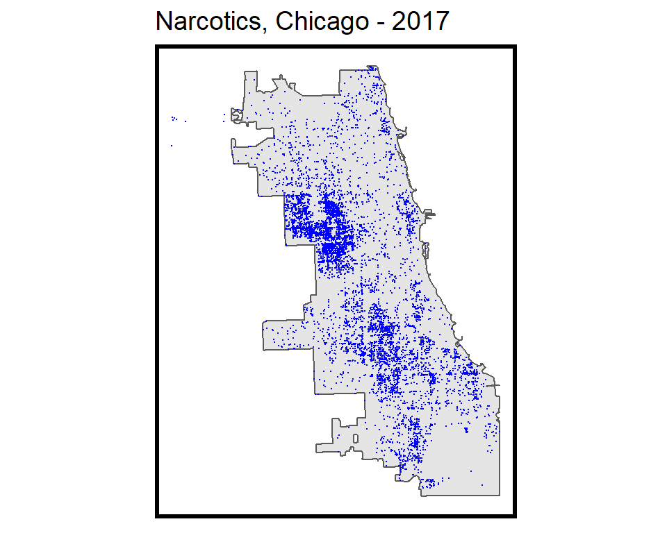

```r
# read nartotics data
narcotics <- read.socrata("https://data.cityofchicago.org/Public-Safety/Crimes-2017/d62x-nvdr") %>%
    filter(Primary.Type == "NARCOTICS") %>% mutate(x = gsub("[()]", "", Location)) %>%
    separate(x, into = c("Y", "X"), sep = ",") %>% mutate(X = as.numeric(X),
    Y = as.numeric(Y)) %>% na.omit %>% st_as_sf(coords = c("X", "Y"), crs = 4326,
    agr = "constant") %>% st_transform(102271) %>% distinct()

ggplot() + geom_sf(data = chicagoBoundary) + geom_sf(data = narcotics, colour = "blue",
    size = 0.1, show.legend = "point") + labs(title = "Narcotics, Chicago - 2017") +
    mapTheme()
```

Figure 1: Distribution of narcotics crime in Chicago in 2017

Crime risk usually varies smoothly across space instead of across community or administrative unit. A 500ft * 500ft grid cell is a more realistic and scientific spatial unit here. Thus, by using `rst_make_grid`, fishnet is created.

```r
# create fishnet, cell size is 500 ft
fishnet <- st_make_grid(chicagoBoundary, cellsize = 500) %>% st_sf()

fishnet <- fishnet[chicagoBoundary, ] %>% mutate(uniqueID = rownames(.)) %>%
    dplyr::select(uniqueID)
```

Then to count the number of narcotics on each grid cell, the crime data is joined to the fishnet.

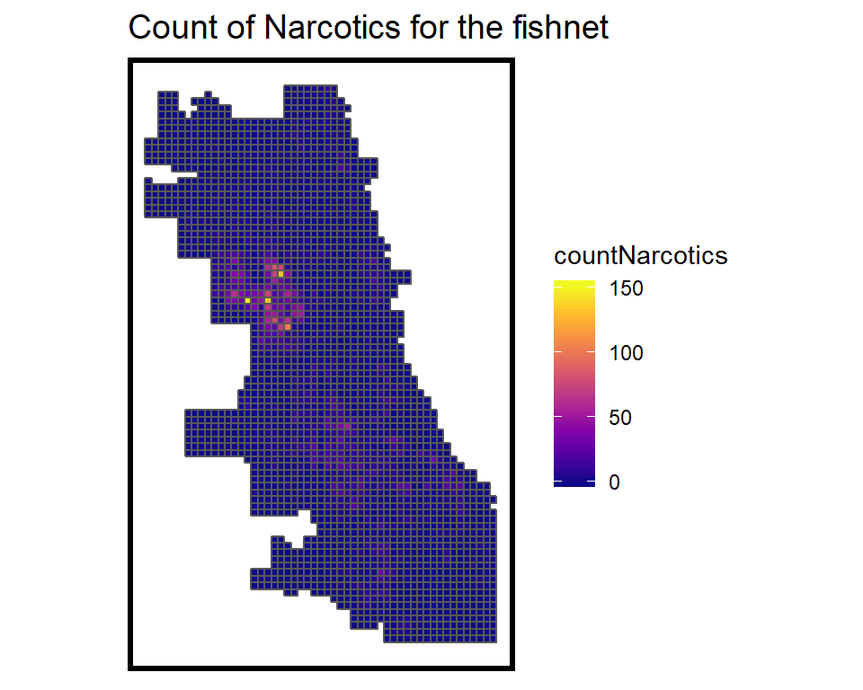

```r
crime_net <- narcotics %>% dplyr::select() %>% mutate(countNarcotics = 1) %>%
    aggregate(., fishnet, sum) %>% mutate(countNarcotics = ifelse(is.na(countNarcotics),
    0, countNarcotics), uniqueID = rownames(.), cvID = sample(round(nrow(fishnet)/24),
    size = nrow(fishnet), replace = TRUE))

ggplot() + geom_sf(data = crime_net, aes(fill = countNarcotics)) + scale_fill_viridis(option = "plasma") +
    labs(title = "Count of Narcotics for the fishnet") + mapTheme()
```

Figure 2: Count of narcotics crime by fishnet

### 2.2 Risk Factors

All the 311 calls related data indicate a decaying community which is likely to be unsafe and full of crimes. From my perspectives, narcotics usually happen with other crimes like gambling and shootings, and thus, I include them into the risk factors.

In this analysis, I prefer using average nearest neighbor distance to measure the local exposure to risk factors. It is sure that counting the total number of each factor falling on a grid cell is feasible, but this approach, only focusing on a rigid scale, fails to gain a general insight. As we said before, the narcotics vary smoothly across space.

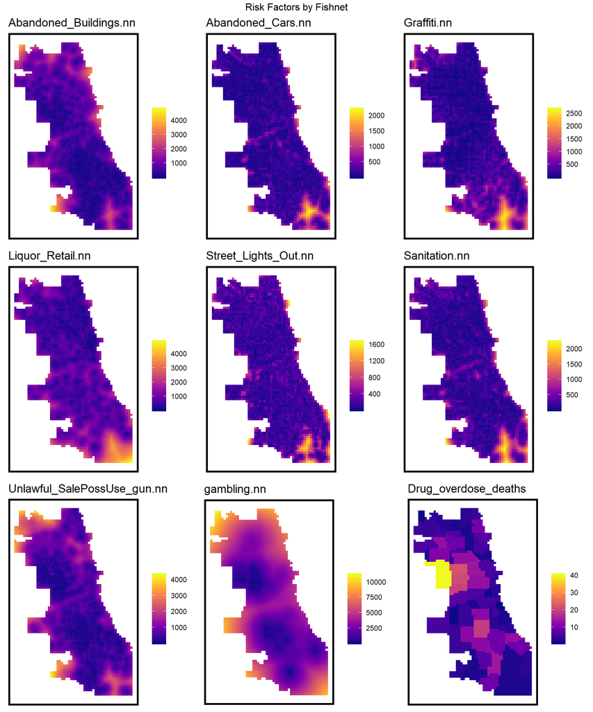

```r
abandonCars <- read.socrata("https://data.cityofchicago.org/Service-Requests/311-Service-Requests-Abandoned-Vehicles/3c9v-pnva") %>%
    mutate(year = substr(creation_date, 1, 4)) %>% filter(year == "2017") %>%
    dplyr::select(Y = latitude, X = longitude) %>% na.omit() %>% st_as_sf(coords = c("X",
    "Y"), crs = 4326, agr = "constant") %>% st_transform(st_crs(fishnet)) %>%
    mutate(Legend = "Abandoned_Cars")

abandonBuildings <- read.socrata("https://data.cityofchicago.org/Service-Requests/311-Service-Requests-Vacant-and-Abandoned-Building/7nii-7srd") %>%
    mutate(year = substr(date_service_request_was_received, 1, 4)) %>% filter(year ==
    "2017") %>% dplyr::select(Y = latitude, X = longitude) %>% na.omit() %>%
    st_as_sf(coords = c("X", "Y"), crs = 4326, agr = "constant") %>% st_transform(st_crs(fishnet)) %>%
    mutate(Legend = "Abandoned_Buildings")

graffiti <- read.socrata("https://data.cityofchicago.org/Service-Requests/311-Service-Requests-Graffiti-Removal-Historical/hec5-y4x5") %>%
    mutate(year = substr(creation_date, 1, 4)) %>% filter(year == "2017") %>%
    filter(where_is_the_graffiti_located_ == "Front" | where_is_the_graffiti_located_ ==
        "Rear" | where_is_the_graffiti_located_ == "Side") %>% dplyr::select(Y = latitude,
    X = longitude) %>% na.omit() %>% st_as_sf(coords = c("X", "Y"), crs = 4326,
    agr = "constant") %>% st_transform(st_crs(fishnet)) %>% mutate(Legend = "Graffiti")

streetLightsOut <- read.socrata("https://data.cityofchicago.org/Service-Requests/311-Service-Requests-Street-Lights-All-Out/zuxi-7xem") %>%
    mutate(year = substr(creation_date, 1, 4)) %>% filter(year == "2017") %>%
    dplyr::select(Y = latitude, X = longitude) %>% na.omit() %>% st_as_sf(coords = c("X",
    "Y"), crs = 4326, agr = "constant") %>% st_transform(st_crs(fishnet)) %>%
    mutate(Legend = "Street_Lights_Out")

sanitation <- read.socrata("https://data.cityofchicago.org/Service-Requests/311-Service-Requests-Sanitation-Code-Complaints-Hi/me59-5fac") %>%
    mutate(year = substr(creation_date, 1, 4)) %>% filter(year == "2017") %>%
    dplyr::select(Y = latitude, X = longitude) %>% na.omit() %>% st_as_sf(coords = c("X",
    "Y"), crs = 4326, agr = "constant") %>% st_transform(st_crs(fishnet)) %>%
    mutate(Legend = "Sanitation")

liquorRetail <- read.socrata("https://data.cityofchicago.org/Community-Economic-Development/Business-Licenses-Cur   rent-Liquor-and-Public-Places/nrmj-3kcf") %>%
    filter(BUSINESS.ACTIVITY == "Retail Sales of Packaged Liquor") %>% dplyr::select(Y = LATITUDE,
    X = LONGITUDE) %>% na.omit() %>% st_as_sf(coords = c("X", "Y"), crs = 4326,
    agr = "constant") %>% st_transform(st_crs(fishnet)) %>% mutate(Legend = "Liquor_Retail")

neighborhoods <- st_read("https://raw.githubusercontent.com/blackmad/neighborhoods/master/chicago.geojson") %>%
    st_transform(st_crs(fishnet))
OverdoseDeath <- read.csv("./Drug_overdose_deaths.csv")
OverdoseDeath$name <- as.character(OverdoseDeath$name)
neighborhoods$name <- as.character(neighborhoods$name)
OverdoseDeath <- neighborhoods %>% left_join(OverdoseDeath, by = "name") %>%
    filter(name != "O'Hare") %>% mutate(Legend = "Drug_overdose_deaths", value = ifelse(is.na(Ave_Annual_Number),
    0, Ave_Annual_Number)) %>% dplyr::select(Legend, geometry, value)

GunSaleUse <- read.socrata("https://data.cityofchicago.org/Public-Safety/Crimes-2017/d62x-nvdr") %>%
    filter(Primary.Type == "WEAPONS VIOLATION" & (Description == "UNLAWFUL SALE HANDGUN" |
        Description == "UNLAWFUL USE HANDGUN" | Description == "UNLAWFUL POSS OF HANDGUN")) %>%
    mutate(x = gsub("[()]", "", Location)) %>% separate(x, into = c("Y", "X"),
    sep = ",") %>% mutate(X = as.numeric(X), Y = as.numeric(Y)) %>% na.omit %>%
    st_as_sf(coords = c("X", "Y"), crs = 4326, agr = "constant") %>% st_transform(102271) %>%
    distinct() %>% mutate(Legend = "Unlawful_SalePossUse_gun")

gambling <- read.socrata("https://data.cityofchicago.org/Public-Safety/Crimes-2017/d62x-nvdr") %>%
    filter(Primary.Type == "GAMBLING") %>% mutate(x = gsub("[()]", "", Location)) %>%
    separate(x, into = c("Y", "X"), sep = ",") %>% mutate(X = as.numeric(X),
    Y = as.numeric(Y)) %>% na.omit %>% st_as_sf(coords = c("X", "Y"), crs = 4326,
    agr = "constant") %>% st_transform(102271) %>% distinct() %>% mutate(Legend = "Gambling")

# for point data
vars_net <- rbind(abandonCars, streetLightsOut, abandonBuildings, liquorRetail,
    graffiti, sanitation, GunSaleUse, gambling) %>% st_join(., fishnet, join = st_within) %>%
    st_set_geometry(NULL) %>% group_by(uniqueID, Legend) %>% summarize(count = n()) %>%
    full_join(fishnet) %>% spread(Legend, count, fill = 0) %>% st_sf() %>% dplyr::select(-`<NA>`) %>%
    na.omit()

# for polygon data
vars_net2 <- rbind(OverdoseDeath) %>% st_join(., fishnet, join = st_intersects) %>%
    spread(Legend, value, fill = 0) %>% na.omit()

vars_net <- vars_net2 %>% dplyr::select(uniqueID, Drug_overdose_deaths) %>%
    st_set_geometry(NULL) %>% merge(., vars_net, by = "uniqueID") %>% st_sf()

nn_function <- function(measureFrom, measureTo, k) {
    measureFrom_Matrix <- as.matrix(measureFrom)
    measureTo_Matrix <- as.matrix(measureTo)
    nn <- get.knnx(measureTo, measureFrom, k)$nn.dist
    output <- as.data.frame(nn) %>% rownames_to_column(var = "thisPoint") %>%
        gather(points, point_distance, V1:ncol(.)) %>% arrange(as.numeric(thisPoint)) %>%
        group_by(thisPoint) %>% summarize(pointDistance = mean(point_distance)) %>%
        arrange(as.numeric(thisPoint)) %>% dplyr::select(-thisPoint) %>% pull()

    return(output)
}

vars_net$Abandoned_Buildings.nn = nn_function(st_coordinates(st_centroid(vars_net)),
    st_coordinates(abandonBuildings), 3)

vars_net$Abandoned_Cars.nn = nn_function(st_coordinates(st_centroid(vars_net)),
    st_coordinates(abandonCars), 3)

vars_net$Graffiti.nn = nn_function(st_coordinates(st_centroid(vars_net)), st_coordinates(graffiti),
    3)

vars_net$Liquor_Retail.nn = nn_function(st_coordinates(st_centroid(vars_net)),
    st_coordinates(liquorRetail), 3)

vars_net$Street_Lights_Out.nn = nn_function(st_coordinates(st_centroid(vars_net)),
    st_coordinates(streetLightsOut), 3)

vars_net$Sanitation.nn = nn_function(st_coordinates(st_centroid(vars_net)),
    st_coordinates(sanitation), 3)

vars_net$Unlawful_SalePossUse_gun.nn = nn_function(st_coordinates(st_centroid(vars_net)),
    st_coordinates(GunSaleUse), 5)

vars_net$gambling.nn = nn_function(st_coordinates(st_centroid(vars_net)), st_coordinates(gambling),
    5)

vars_net.long.nn <- vars_net %>% dplyr::select(ends_with(".nn"), Drug_overdose_deaths,
    uniqueID) %>% gather(Variable, value, -geometry, -uniqueID)

vars <- unique(vars_net.long.nn$Variable)
mapList <- list()

for (i in vars) {
    mapList[[i]] <- ggplot() + geom_sf(data = filter(vars_net.long.nn, Variable ==
        i), aes(fill = value), colour = NA) + scale_fill_viridis(option = "plasma",
        name = "") + labs(title = i) + mapTheme()
}

do.call(grid.arrange, c(mapList, ncol = 3, top = "Risk Factors by Fishnet"))
```

Figure 3: Risk factors by fishnet

In addition to factors mentioned above, distance to the centroid of Garfield Park neigbor is taken into account. After doing some research about drug trafficking in Chicago, I find that there are many drug trades happen here (Pulaski Rd from I-290 to Lake St).

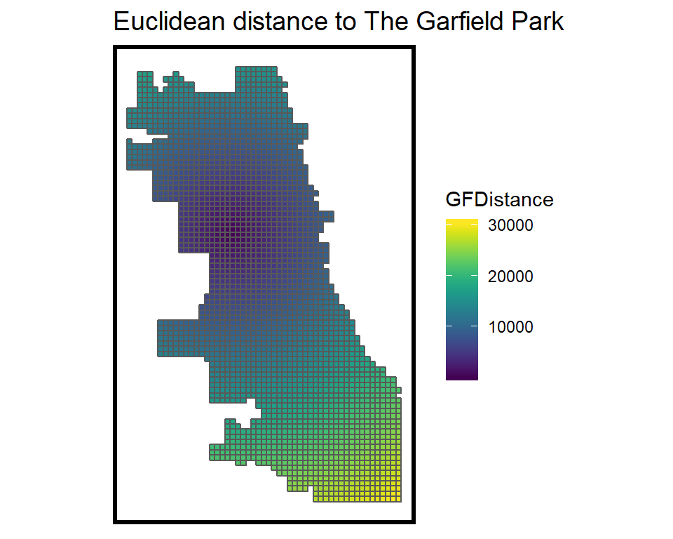

```r
GFPoint <- neighborhoods %>% filter(name == "Garfield Park") %>% st_centroid()

vars_net$GFDistance = st_distance(st_centroid(vars_net), GFPoint) %>% as.numeric()

ggplot() + geom_sf(data = vars_net, aes(fill = GFDistance)) + scale_fill_viridis() +
    labs(title = "Euclidean distance to The Garfield Park") + mapTheme()
```

Figure 4: Euclidean Distance to The Centroid of Garfield Park

With all the factors are set up, I then join the narcotics by fishnet data and risk factors by fishnet data and the final fishnet data is named as `rfinal_net`. To explore the spatial structure of the drug crime, neighborhood `rname` is spatially joined to the `rfinal_net`.

```r
final_net <- left_join(crime_net, st_set_geometry(vars_net, NULL), by = "uniqueID")

final_net <- st_centroid(final_net) %>% st_join(., dplyr::select(neighborhoods,
    name)) %>% st_set_geometry(NULL) %>% left_join(dplyr::select(final_net,
    geometry, uniqueID)) %>% st_sf() %>% na.omit()
```

## 3 Spatial Structure of Narcotics

Local Moran’s I of narcotics is calculated using Queen weight matrix. Figure 5 shows the spatial process of interest. For those grid cells where p-value < 0.05, the I are significantly different from 0 and there is a spatial autocorrelation at these location.

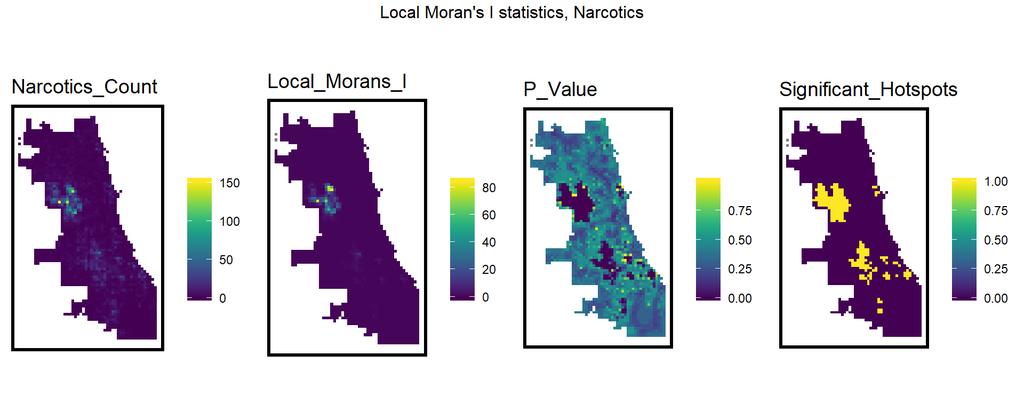

```r
final_net.nb <- poly2nb(final_net, queen = TRUE)
final_net.weights <- nb2listw(final_net.nb, style = "W", zero.policy = TRUE)

final_net.localMorans <- cbind(as.data.frame(localmoran(final_net$countNarcotics,
    final_net.weights)), as.data.frame(final_net, NULL)) %>% st_sf() %>% dplyr::select(Narcotics_Count = countNarcotics,
    Local_Morans_I = Ii, P_Value = `Pr(z > 0)`) %>% mutate(Significant_Hotspots = ifelse(P_Value <=
    0.05, 1, 0)) %>% gather(Variable, Value, -geometry)

vars <- unique(final_net.localMorans$Variable)
varList <- list()

for (i in vars) {
    varList[[i]] <- ggplot() + geom_sf(data = filter(final_net.localMorans,
        Variable == i), aes(fill = Value), colour = NA) + scale_fill_viridis(name = "") +
        labs(title = i) + mapTheme()
}

do.call(grid.arrange, c(varList, ncol = 4, top = "Local Moran's I statistics, Narcotics"))
```

Figure 5: Local Moran’s I Statistics

Including Spatial structure features into models usually makes the predictions more accurate and generalizable by accounting for the selection bias. In this case, `rnarcotiv.isSig` and `rnarcotics.isSig.dist` are created. `rnarcotics.isSig` denotes the significant areas in Chicago where there is a clustering of narcotics. `rnarcotics.isSig.dist` stands for the distance each grid cell to its nearest significant cluster. As shown in Figure 6, the narcotics dissipate in a linear fashion from the hotspot(or significant clusters) outward.

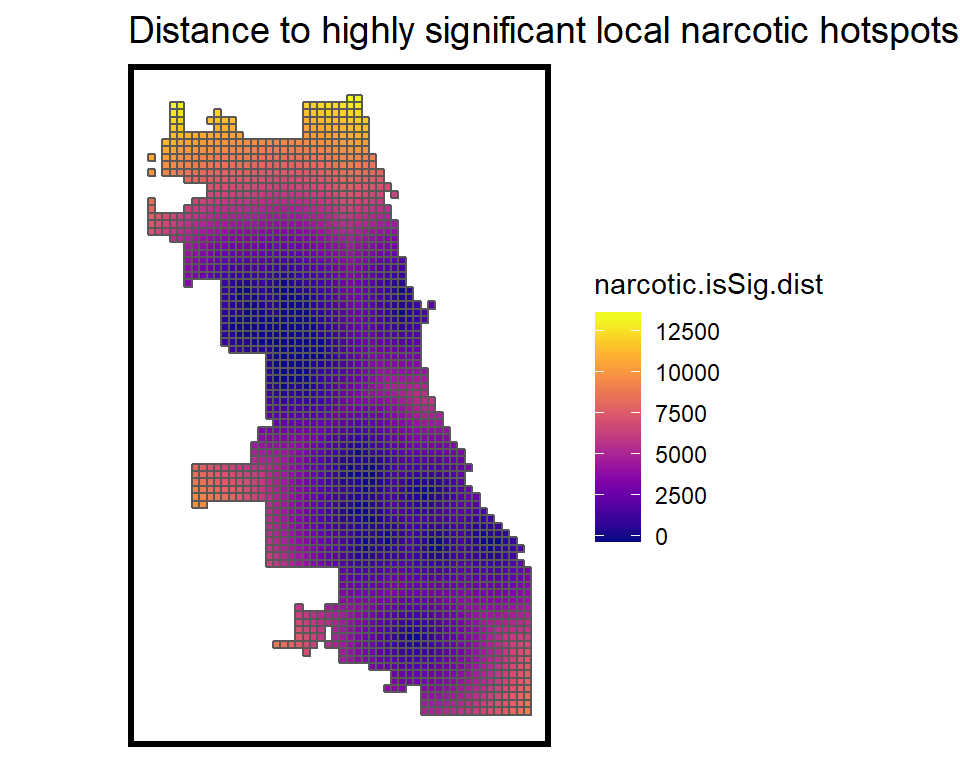

```r
final_net <- final_net %>% mutate(narcotic.isSig = ifelse(localmoran(final_net$countNarcotics,
    final_net.weights)[, 5] <= 1e-07, 1, 0)) %>% mutate(narcotic.isSig.dist = nn_function(st_coordinates(st_centroid(final_net)),
    st_coordinates(st_centroid(filter(final_net, narcotic.isSig == 1))), 1))

ggplot() + geom_sf(data = final_net, aes(fill = narcotic.isSig.dist)) + scale_fill_viridis(option = "plasma") +
    labs(title = "Distance to highly significant local narcotic hotspots") +
    mapTheme()
```

Figure 6: Distance to Highly Significant Areas

## 4 Correlation Tests

Figure 7 shows a small multiple scatterplot of `rcountNarcotics` as a function of risk factors. Basically, drug crime count are associated with these selected factors.

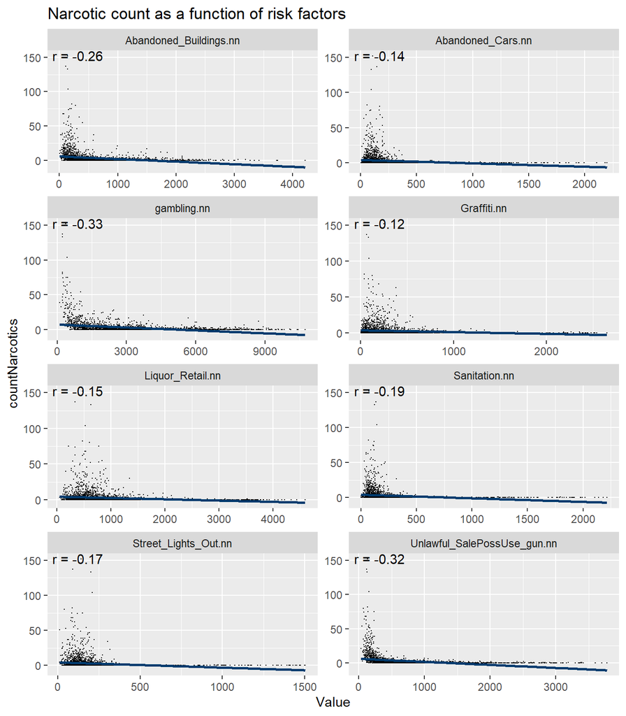

```r
correlation.long <- st_set_geometry(final_net, NULL) %>% dplyr::select(countNarcotics,
    ends_with(".nn")) %>% gather(Variable, Value, -countNarcotics)

correlation.cor <- correlation.long %>% group_by(Variable) %>% summarize(correlation = cor(Value,
    countNarcotics, use = "complete.obs"))

ggplot(correlation.long, aes(Value, countNarcotics)) + geom_point(size = 0.1) +
    geom_text(data = correlation.cor, aes(label = paste("r =", round(correlation,
        2))), x = -Inf, y = Inf, vjust = 1, hjust = -0.1) + geom_smooth(method = "lm",
    se = FALSE, colour = "#013b6e") + facet_wrap(~Variable, ncol = 2, scales = "free") +
    labs(title = "Narcotic count as a function of risk factors")
```

Figure 7: Narcotic count as a function of risk factors

## 5 Poisson Regression

### 5.1 Distribution of Narcotics

When chosing the regression model, the distribution of narcotics count is plotted in histogram. To better figure out, I omit the grid cells with a `rcountNarcotics` higher than 30. It is obvious that OLS is no longer appropriate here and thus Poisson regression model is built.

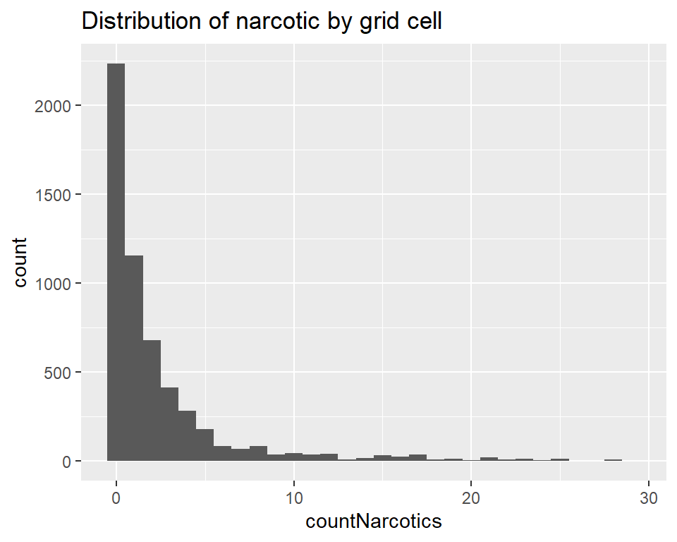

```r
ggplot(subset(final_net, final_net$countNarcotics < 30), aes(countNarcotics)) +
    geom_histogram(binwidth = 1) + labs(title = "Distribution of narcotic by grid cell")
```

Figure 8: Distribution of narcotics by fishnet

### 5.2 Accuracy and Generalizability

In this section, cross validation is conducted to test the the first type generalizability*(There are two type of generalizability: 1) the model should also perform well when applied to unseen data; 2) it should be equally accurate across different urban context in this instance.)*. Random k-fold and spatial cross validation are both used here. In random k-fold cross validation, dataset is grouped into k folds randomly and the model is trained with k-1 folds for k times. After each training, the predicted value for the excluded fold is recorded in `rallPredictions`. In spatial cross validation, the process is similar to that of random k fold, but data folds are obtained in a different way, i.e., based on their location. Here, the dataset is divided by the neightborhoods name the centroid of the cell falls within*(Code shown in section 2.2)*.

```r
reg.vars <- c("Abandoned_Buildings.nn", "Abandoned_Cars.nn", "Graffiti.nn",
    "Liquor_Retail.nn", "Street_Lights_Out.nn", "Sanitation.nn", "GFDistance",
    "Drug_overdose_deaths", "Unlawful_SalePossUse_gun.nn", "gambling.nn")

crossValidate <- function(dataset, id, dependentVariable, indVariables) {

    allPredictions <- data.frame()
    cvID_list <- unique(dataset[[id]])

    for (i in cvID_list) {

        thisFold <- i

        fold.train <- filter(dataset, dataset[[id]] != thisFold) %>% as.data.frame() %>%
            dplyr::select(id, geometry, indVariables, dependentVariable)
        fold.test <- filter(dataset, dataset[[id]] == thisFold) %>% as.data.frame() %>%
            dplyr::select(id, geometry, indVariables, dependentVariable)

        regression <- glm(countNarcotics ~ ., family = "poisson", data = fold.train %>%
            dplyr::select(-geometry, -id))

        thisPrediction <- mutate(fold.test, Prediction = predict(regression,
            fold.test, type = "response"))

        allPredictions <- rbind(allPredictions, thisPrediction)

    }
    return(st_sf(allPredictions))
}

reg.cv <- crossValidate(dataset = final_net, id = "cvID", dependentVariable = "countNarcotics",
    indVariables = reg.vars) %>% dplyr::select(cvID = cvID, countNarcotics,
    Prediction, geometry)

reg.spatialCV <- crossValidate(dataset = final_net, id = "name", dependentVariable = "countNarcotics",
    indVariables = reg.vars) %>% dplyr::select(cvID = name, countNarcotics,
    Prediction, geometry)
```

Spatial structure is added into the consideration to see whether the new model can reduce the selection bias.

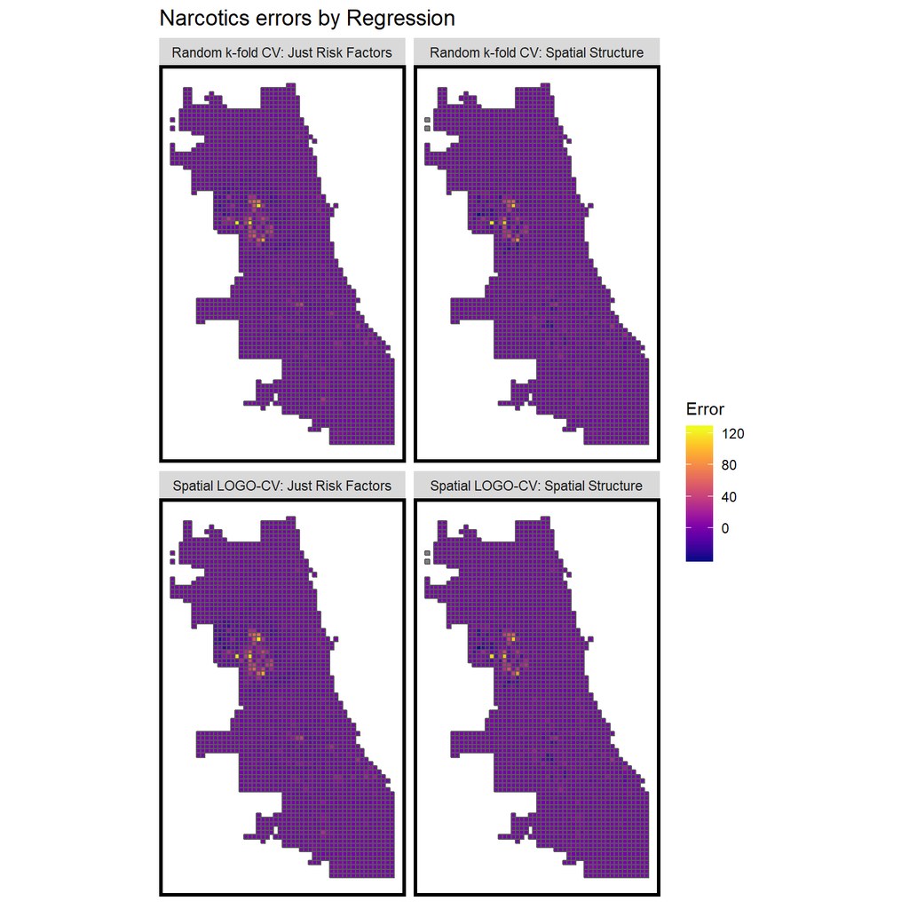

```r
reg.summary <- rbind(mutate(reg.cv, Error = countNarcotics - Prediction, Regression = "Random k-fold CV: Just Risk Factors"),
    mutate(reg.spatialCV, Error = countNarcotics - Prediction, Regression = "Spatial LOGO-CV: Just Risk Factors"),
    mutate(reg.ss.cv, Error = countNarcotics - Prediction, Regression = "Random k-fold CV: Spatial Structure"),
    mutate(reg.ss.spatialCV, Error = countNarcotics - Prediction, Regression = "Spatial LOGO-CV: Spatial Structure")) %>%
    st_sf()

reg.summary %>% ggplot() + geom_sf(aes(fill = Error)) + facet_wrap(~Regression) +
    scale_fill_viridis(option = "plasma") + labs(title = "Narcotics errors by Regression") +
    mapTheme()
```

Figure 9: Model errors by random k-fold and spatial cross validation

Mean Absolute Error (MAE) is used here to measure the goodness of fit of two models. MAE is the average of the absolute model errors. Based on Table 1, these models err by roughly 1.9 narcotics, on an absolute basis, on average. For context, the mean `rcountNarcotics` is 3.4325. Besides, raw errors are also important here because MAE fail to provide an insight into whether the model overpredict or underpredict the values. This raises a problem when predicting the crime since overpredicting might draw undue attention to minority neighborhoods. Thus, in the coming section, I will focus on the raw errors.

With the spatial structure in our model, the MAE reduce obviously and it is conlude that the spatial process of narcotics can help in reducing reporting bias and make model more generalizable.

Table 1: MAE and standard deviation MAE by cross validation type

```r
st_set_geometry(reg.summary, NULL) %>% group_by(Regression) %>% summarize(MAE = round(mean(abs(Prediction -
    countNarcotics), na.rm = T), 2), SD_MAE = round(sd(abs(Prediction - countNarcotics),
    na.rm = T), 2)) %>% kable(caption = "MAE by regression") %>% kable_styling("striped",
    full_width = F) %>% row_spec(2, color = "white", background = "#31688EFF") %>%
    row_spec(4, color = "white", background = "#31688EFF")
```

MAE by regression

| Regression | MAE | SD_MAE |
| --- | --- | --- |
| Random k-fold CV: Just Risk Factors | 2.26 | 4.97 |
| Random k-fold CV: Spatial Structure | 1.88 | 4.29 |
| Spatial LOGO-CV: Just Risk Factors | 2.37 | 5.22 |
| Spatial LOGO-CV: Spatial Structure | 1.89 | 4.37 |

### 5.3 Generalizability by neighborhood context

In this section, I will test the second type generalizability(mentioned in section 5.2). Recall that systematic over-policing of certain communities may lead to a reporting or selection bias, which may further effect the result of the prediction.

2017 5-year ACS race data is used here. As shown in Figure 10, Chicago is a segregated city and has an obvious racail clustering.

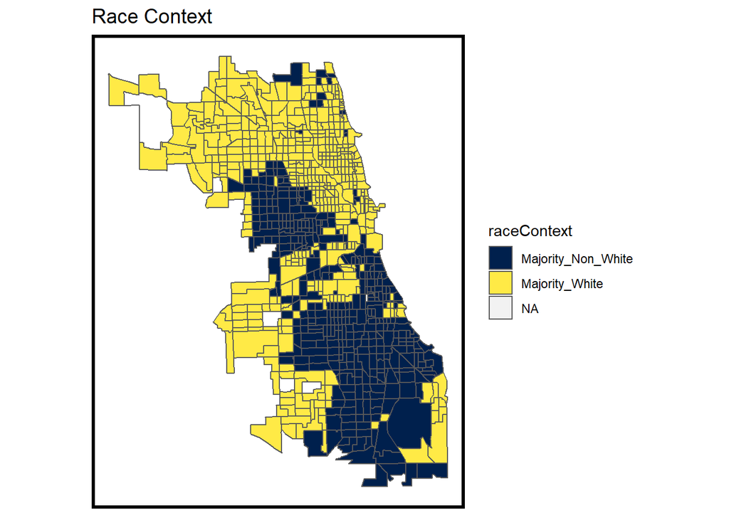

```r
ggplot() + geom_sf(data = tracts17, aes(fill = raceContext)) + scale_fill_viridis(option = "cividis",
    discrete = TRUE) + labs(title = "Race Context", name = "Race Context") +
    mapTheme()
```

```r
final_reg <- filter(reg.summary, Regression == "Spatial LOGO-CV: Spatial Structure" |
    Regression == "Spatial LOGO-CV: Just Risk Factors") %>% mutate(uniqueID = rownames(.))

final_reg.tracts <- st_join(st_centroid(final_reg), tracts17) %>% st_set_geometry(NULL) %>%
    left_join(dplyr::select(final_reg, uniqueID)) %>% st_sf() %>% na.omit()
```

Figure 10: Race context in Chicago

It is easy to say whether the model is overpredicting or underpredicting the crime in each neighborhoods with raw errors. Apparently, this risk prediction model underpredicts in `rMajority_Non_White` neighborhoods, but overpredicts in `rMajority_White` neighborhoods. To my surprise, the mean error of the model accounting for the spatial features is even higher than that of the model with only risk factors. Notabaly, the difference in error across neighborhood context is much higher too. This means that the model with spatial structure factors even make the prediction worse.

Table 2: Raw errors by race context

```r
st_set_geometry(final_reg.tracts, NULL) %>% group_by(Regression, raceContext) %>%
    summarize(mean.Error = mean(Error, na.rm = T)) %>% spread(raceContext, mean.Error) %>%
    kable(caption = "Mean Error by neighborhood racial context") %>% kable_styling("striped",
    full_width = F) %>% row_spec(2, color = "white", background = "#31688EFF")
```

Mean Error by neighborhood racial context

| Regression | Majority_Non_White | Majority_White |
| --- | --- | --- |
| Spatial LOGO-CV: Just Risk Factors | 0.1943945 | -0.1943299 |
| Spatial LOGO-CV: Spatial Structure | 0.2565520 | -0.2177487 |

## 6 New Model or Traditional Crime Hotspots?

Police department nowadays target the police resources to the areas where crime is concentrated based on the traditional kernal density hotspot mapping. Here a new indicator is created to illustrate whether the risk predictions capture more of the observed narcotics relative to kernal density. Basically, the more data point fall in category 90% to 100%, the better the model is. In this scenario, the police department could allocate the resource in a more targeting way based on the predictions result.

Left figure in Figure 11 is the kernel density hotspot map. In kernal density map, the value of each grid cell is equal to the sum of all the kernals that underlie it. Since search radius is set as 1000ft here, that is cells have many points in 1000ft will have relatively high kernal density.

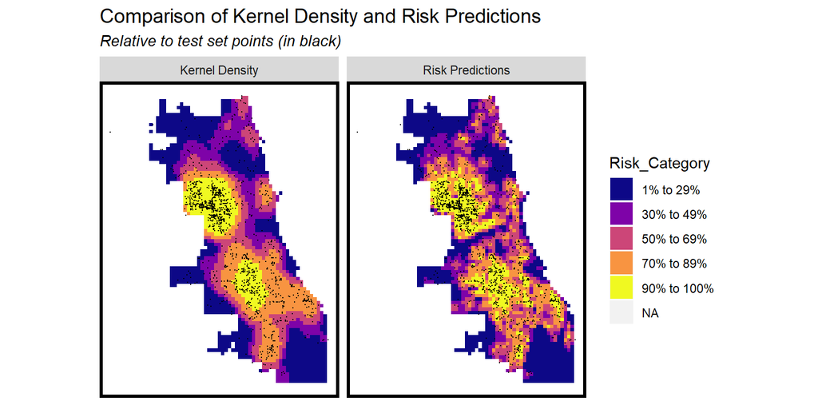

```r
library(raster)
# Compute kernel density
nct_ppp <- as.ppp(st_coordinates(narcotics), W = st_bbox(final_net))
nct_KD <- spatstat::density.ppp(nct_ppp, 1000)
# Convert kernel density to grid cells taking the mean
nct_KDE_sf <- as.data.frame(nct_KD) %>% st_as_sf(coords = c("x", "y"), crs = st_crs(final_net)) %>%
    aggregate(., final_net, mean) %>% # Mutate the Risk_Category field as defined below.
mutate(label = "Kernel Density", Risk_Category = ntile(value, 100), Risk_Category = case_when(Risk_Category >=
    90 ~ "90% to 100%", Risk_Category >= 70 & Risk_Category <= 89 ~ "70% to 89%",
    Risk_Category >= 50 & Risk_Category <= 69 ~ "50% to 69%", Risk_Category >=
        30 & Risk_Category <= 49 ~ "30% to 49%", Risk_Category >= 1 & Risk_Category <=
        29 ~ "1% to 29%")) %>% # Bind to a layer where test set crime counts are spatially joined to the
# fisnnet.
bind_cols(aggregate(dplyr::select(narcotics) %>% mutate(nctCount = 1), ., length) %>%
    mutate(nctCount = replace_na(nctCount, 0))) %>% # Select the fields we need
dplyr::select(label, Risk_Category, nctCount)

nct_risk_sf <- filter(final_reg, Regression == "Spatial LOGO-CV: Spatial Structure") %>%
    mutate(label = "Risk Predictions", Risk_Category = ntile(Prediction, 100),
        Risk_Category = case_when(Risk_Category >= 90 ~ "90% to 100%", Risk_Category >=
            70 & Risk_Category <= 89 ~ "70% to 89%", Risk_Category >= 50 & Risk_Category <=
            69 ~ "50% to 69%", Risk_Category >= 30 & Risk_Category <= 49 ~ "30% to 49%",
            Risk_Category >= 1 & Risk_Category <= 29 ~ "1% to 29%")) %>% bind_cols(aggregate(dplyr::select(narcotics) %>%
    mutate(nctCount = 1), ., length) %>% mutate(nctCount = replace_na(nctCount,
    0))) %>% dplyr::select(label, Risk_Category, nctCount)

rbind(nct_KDE_sf, nct_risk_sf) %>% gather(Variable, Value, -label, -Risk_Category,
    -geometry) %>% ggplot() + geom_sf(aes(fill = Risk_Category), colour = NA) +
    geom_sf(data = sample_n(narcotics, 1500), size = 0.1, colour = "black") +
    facet_wrap(~label, ) + scale_fill_viridis(option = "plasma", discrete = TRUE) +
    labs(title = "Comparison of Kernel Density and Risk Predictions", subtitle = "Relative to test set points (in black)") +
    mapTheme()
```

Figure 11: Maps of kernel density and risk predictions

To better compare the two methods, the rate of narcotic points by risk category and model type is calculated and plotted. It is safe to draw a conclusion that the risk predictions capture a much greater share of observed narcotic events in the highest risk category relative to the kernel density and thus in this case, new model perform well.

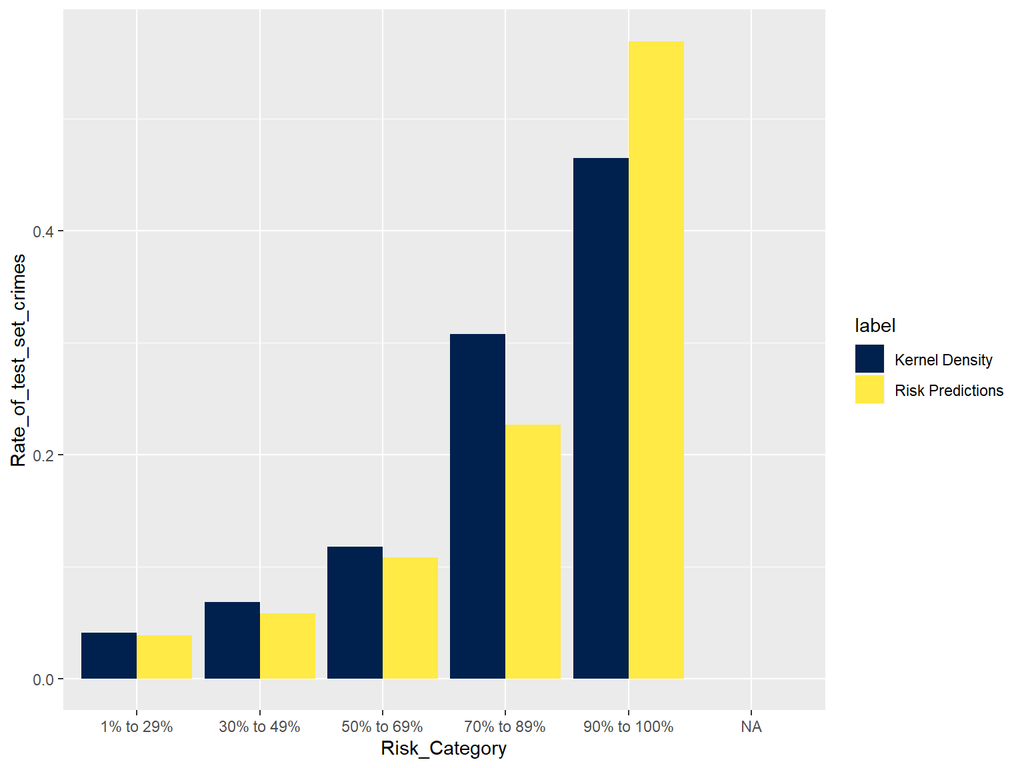

```r
rbind(nct_KDE_sf, nct_risk_sf) %>% st_set_geometry(NULL) %>% gather(Variable,
    Value, -label, -Risk_Category) %>% group_by(label, Risk_Category) %>% summarize(countNarcotics = sum(Value)) %>%
    ungroup() %>% group_by(label) %>% mutate(Rate_of_test_set_crimes = countNarcotics/sum(countNarcotics)) %>%
    ggplot(aes(Risk_Category, Rate_of_test_set_crimes)) + geom_bar(aes(fill = label),
    position = "dodge", stat = "identity") + scale_fill_viridis(option = "cividis",
    discrete = TRUE)
```

Figure 12: Comparison of kernel density and risk predictions in barplot

## 7 Conlusion

From what has been discussed above, the risk prediction model yield a better prediction result than the existing hotspot mapping. Here, better means a more targeted prodiction for a small scale. Instead of obtaing a rough data for the neighbor, our model provide a more specific result for each space unit. Howevr, the MAE value of risk prediction model is relatively high, given that the mean `rcountNarcotics` is about 3.5, I will not recommand it to the police department especially if they want to allocate the resources based on the prediction.

In the new model, spatial process of the crime is taken into account, which did not make the model more generalizable and accurate as expected. Though the MAE is acceptable and reduced by adding spatial structure features, the model reports a high difference in error across neighborhood context. The racial bias in model is strong here since there are under-predicting in non-White neighbors and over-predicting in White neighbors. Based on the compasion of the kernel density model and the risk prediction model, we are happy to see that the latter one is more targeted and capture more of the observed narcotics relative to the kernel density. Thus, I would definitely recommand the risk prediction model itself but not our model as an alternative to the kernel density, but the risk factors selection should be done after more consideration.